# MPP-E1180 Lecture 8: Automatic Tables and Static Visualisation

21 October 2016

## Objectives for the week

- Review
- Static results presentation
  - Automatic table creation
  - Plotting best practices
  - ggplot2 for general graphing

## Motivation

Today we will learn how to **communicate your research findings** with automatically generated tables and static plots.

Why automatically generate?

- **Saves time**: don't have to re-enter numbers by hand into a table or restyle a graph each time you change the data/analysis.
- Easier to **find and correct errors**: all source code that created all tables and figures is linked and output updated when corrections are made.
- **More reproducible**: everything is clearly linked together.

## General process

In general include the functions to create the tables/figures in a code chunk.

Include in the **code chunk head** `echo=FALSE, warning=FALSE, error=FALSE, message=FALSE`.

You may need to also include `results='asis'` for some table functions.

See previous weeks 4 and 5 for figure code chunk options.

## Automatic table generation

There are a number of tools for automatically generating tables in R/R Markdown.

- `kable` in the knitr package
- [xtable](http://cran.r-project.org/web/packages/xtable/vignettes/xtableGallery.pdf) package
- [texreg](http://www.jstatsoft.org/v55/i08/paper) package
- [stargazer](http://cran.r-project.org/web/packages/stargazer/stargazer.pdf) package

## Today

We will focus on `kable` and `stargazer`.

- `kable` is a good, **simple** tool for creating tables from **data frames** (or matrices).
- `stargazer` is useful for creating more complex tables of **regression model output**.

**Example Docs**: [HertieDataScience/Examples/PaperWithRegressionTables](https://github.com/HertieDataScience/Examples/tree/master/PaperWithRegressionTables)

## `kable` example: predicted probabilities

```r
# Load data
URL <- 'http://www.ats.ucla.edu/stat/data/binary.csv'
Admission <- read.csv(URL)

# Estimate model
Logit1 <- glm(admit ~ gre + gpa + as.factor(rank),
              data = Admission, family = 'binomial')

# Create fitted data
fitted <- with(Admission,
               data.frame(gre = mean(gre),
                          gpa = mean(gpa),
                          rank = factor(1:4)))
```

## `kable` example: predicted probabilities

```r
library(knitr)
fitted$predicted <- predict(Logit1, newdata = fitted,
                            type = 'response')
kable(fitted)
```

| gre | gpa | rank | predicted |
| --- | --- | --- | --- |
| 587.7 | 3.3899 | 1 | 0.5166016 |
| 587.7 | 3.3899 | 2 | 0.3522846 |
| 587.7 | 3.3899 | 3 | 0.2186120 |
| 587.7 | 3.3899 | 4 | 0.1846684 |

## `kable` example: predicted probabilities

You can stylise the table.

```r
kable(fitted, align = 'c', digits = 2,
      caption = 'Predicted Probabilities for Fitted Values')
```

Predicted Probabilities for Fitted Values

| gre | gpa | rank | predicted |
| --- | --- | --- | --- |
| 587.7 | 3.39 | 1 | 0.52 |
| 587.7 | 3.39 | 2 | 0.35 |
| 587.7 | 3.39 | 3 | 0.22 |
| 587.7 | 3.39 | 4 | 0.18 |

## Note

**Don't** show more digits to the right of the decimal than are statistically and substantively meaningful.

**A rule of thumb**: more than one or two digits are rarely meaningful.

See also: http://andrewgelman.com/2012/07/02/moving-beyond-hopeless-graphics/

## Show regression output with `stargazer`

`kable` is limited if we want to create regression output tables, especially for multiple models.

`stargazer` is good for this.

## `stargazer` example

Estimate models

```r
L1 <- glm(admit ~ gre,
              data = Admission, family = 'binomial')

L2 <- glm(admit ~ gre + gpa,
              data = Admission, family = 'binomial')

L3 <- glm(admit ~ gre + gpa + as.factor(rank),
              data = Admission, family = 'binomial')
```

## `stargazer` example HTML

When you are creating a table for an HTML doc with stargazer use:

- `type = 'html'`

```r
# Create cleaner covariate labels
labels <- c('GRE Score', 'GPA Score',
            '2nd Ranked School', '3rd Ranked School',
            '4th Ranked School', '(Intercept)')

stargazer::stargazer(L1, L2, L3, covariate.labels = labels,
    title = 'Logistic Regression Estimates of Grad School Acceptance',
    digits = 2, type = 'html')
```

## `stargazer` example HTML

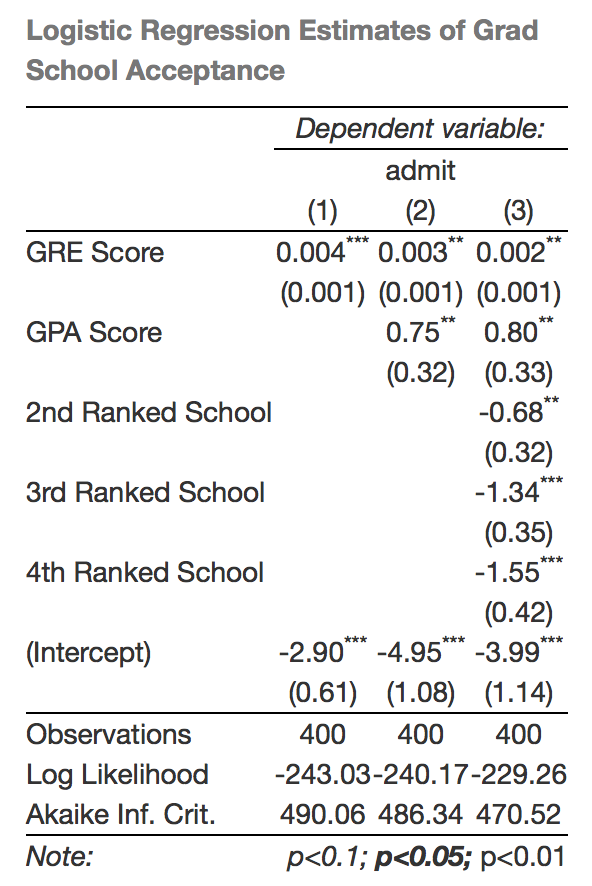

## `stargazer` example PDF

**When you are creating a PDF** use the arguments:

- `type = 'latex'`
- `header = FALSE`

```r
# Create cleaner covariate labels
labels <- c('GRE Score', 'GPA Score',
            '2nd Ranked School', '3rd Ranked School',
            '4th Ranked School', '(Intercept)')

stargazer::stargazer(L1, L2, L3, covariate.labels = labels,
    title = 'Logistic Regression Estimates of Grad School Acceptance',
    digits = 2, type = 'latex', header = FALSE)
```

## `stargazer` output in PDF

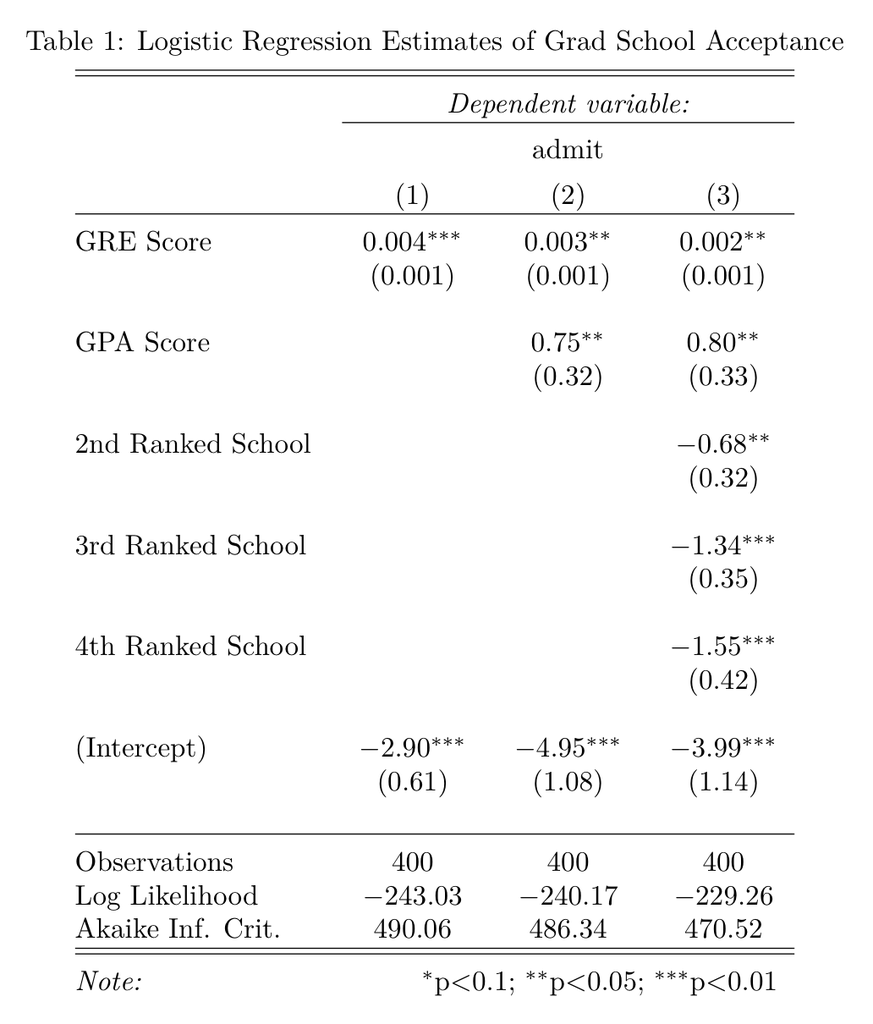

## `stargazer` plain text output

You may want to compare multiple models at once in your R console, use `stargazer` with `type = 'text'`:

```r
stargazer(L1, L2, L3, type = 'text')
```

## Showing Results with Figures

Tables **are important** to include so that readers can **explore details**, but are **usually not the best way** to show your results.

**Figures** are often more effective.

## General principles

(A Selection of) Tufte's Principles for Excellent Statistical Graphics (2001, 13):

- Show the data
- Encourage the eye to compare **differences** in the data
- Serve a clear purpose
- Avoid distorting the data
- Be closely integrated with the text

## Show the data

Show the data, not other things like silly graphics or unnecessary words.

Have a high **data ink** ratio:

\[ \mathrm{Data\:Ink\:Ratio} = \mathrm{\frac{data - ink}{total\:ink}} \]

## Encourage the eye to compare differences

How did the budgets change? (Orange is 2013, Blue is 2012)

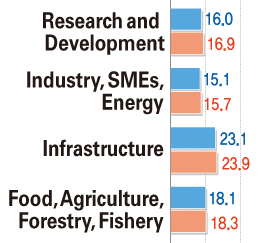

## A little better

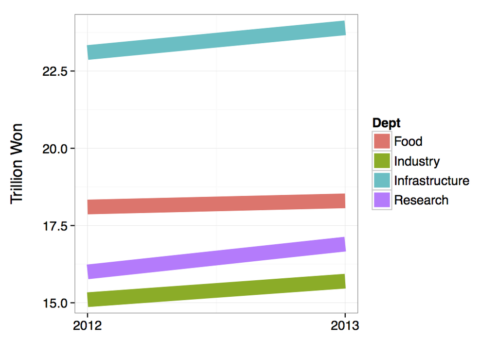

## Even better

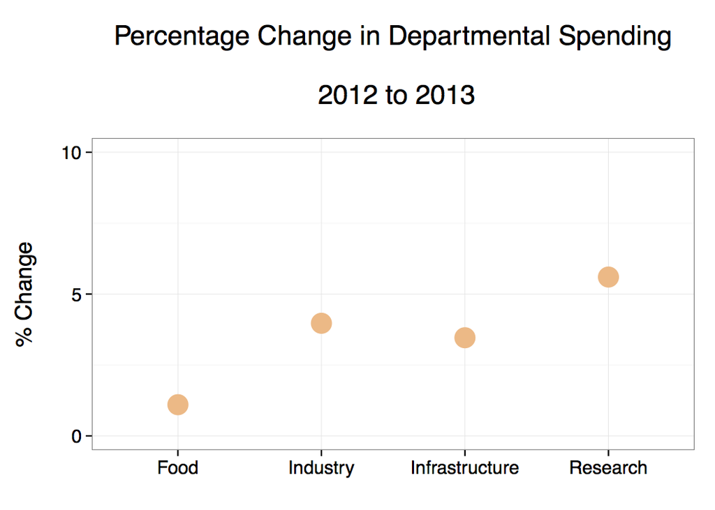

## Avoid distorting the data: special case circles

In general: Avoid using the **size** of a circle to mean something!

So, avoid:

- bubble charts
- pie charts

## Why avoid circles?

Circles can distort data.

- It is difficult to compare their size.
- The Ebbinghause Illusion!

Order the circles from smallest to largest.

The circles are on a scale of 0-100, so what are their values?

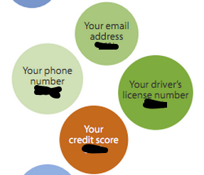

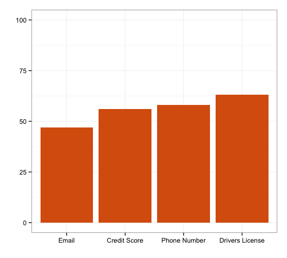

## Ebbinghause Illusion

Which circle is bigger?

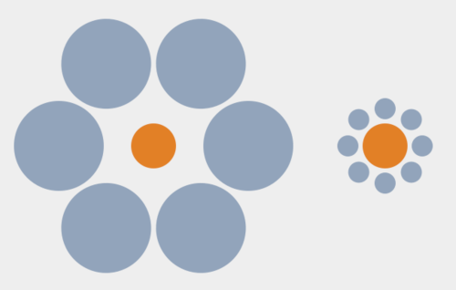

## Colours and Data Distortions

Which square is darkest?

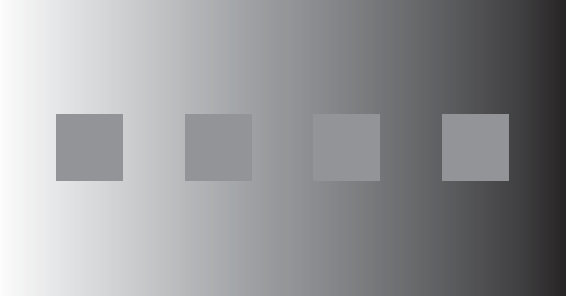

## Colour Principles

**Only** give graphical features (e.g. bars in a bar chart) different colours if it **means something** in the data.

## Colour Principles

Colours should be used to:

- highlight particular data,
- group items,
- encode quantitative values
  - Values of continuous variables should be represented using **increasing hues of the same colour**.
  - Categorical variables should be represented with **different colours**. (rule of thumb: avoid using more than about 7 colours in a plot)

## Bad

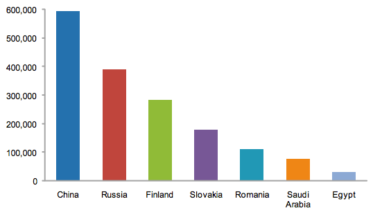

## Good

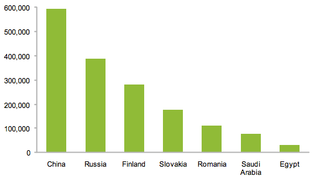

## Colours and accessibility

**Color Blindness**

People who are colour blind can have difficulty distinguishing between **red-green** and **blue-yellow**.

About 5-8% of men are colour blind.

We need to choose colour schemes for our graphics that are **colour blind friendly**.

For more information see http://www.usability.gov/get-involved/blog/2010/02/color-blindness.html.

## Selecting colors

Color Brewer is a great resource for selecting colours: http://colorbrewer2.org/.

## A more systematic introduction to ggplot2

"gg" means "Grammar of Graphics".

"2" just means that it is the second one.

## ggplot2 syntax

Each plot is made of **layers**. Layers include the coordinate system (x-y), points, labels, etc.

Each layer has **aesthetics** (`aes`) including the x & y, size, shape, and colour.

The **main layer types** are called **geometrics** (`geom`). These include lines, points, density plots, bars, and text.

## ggplot2 examples setup

```r
library(devtools)
library(ggplot2)

source_url("http://bit.ly/OTWEGS")

# Create data with no missing values of infant mortality
InfantNoMiss <- subset(MortalityGDP,
                           !is.na(InfantMortality))

# Create High/Low Income Variable
InfantNoMiss$DumMort[InfantNoMiss$InfantMortality
                     >= 15] <- "high"
InfantNoMiss$DumMort[InfantNoMiss$InfantMortality
                     < 15] <- "low"
```

## Simple example

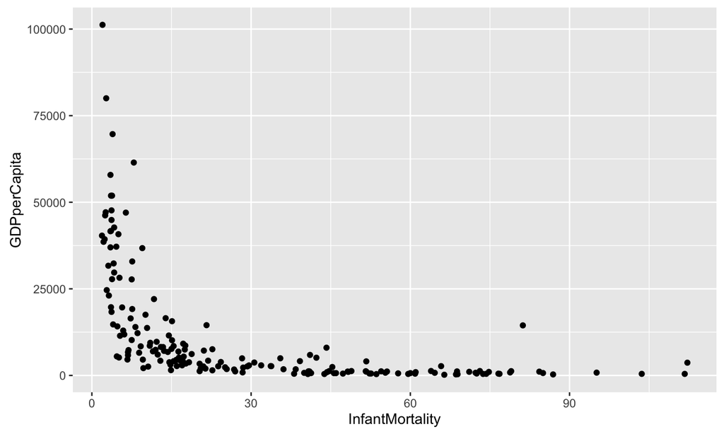

```r
ggplot(data = MortalityGDP, aes(x = InfantMortality,
        y = GDPperCapita)) + geom_point()
```

## Simple example with BW theme

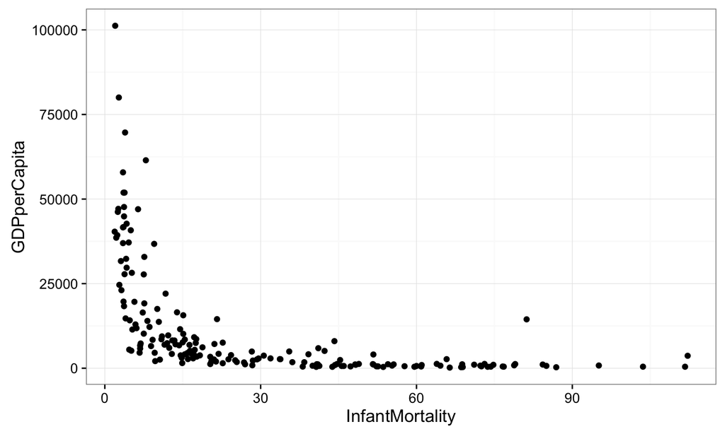

```r
ggplot(data = MortalityGDP, aes(x = InfantMortality,
        y = GDPperCapita)) + geom_point() + theme_bw(base_size = 13)
```

## Colours

There are a number of ways to specify colours in ggplot2.

The simplest way is to let ggplot choose the colours for you.

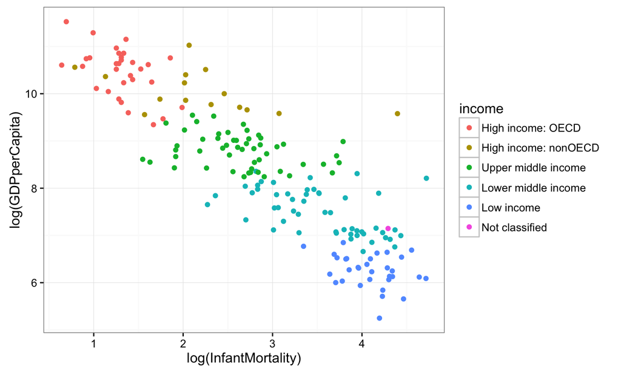

```r
ggplot(data = InfantNoMiss, aes(log(InfantMortality),
                                log(GDPperCapita))) +
      geom_point(aes(colour = income)) +
      theme_bw()
```

## Selecting colours

There are many ways to pick specific colors.

In this class we will mainly use **hexadecimal** colours.

This is probably the most commonly used system for choosing colours on the web.

Every colour is given six digits.

A good website for getting hexadecimal colour schemes is: http://colorbrewer2.org/.

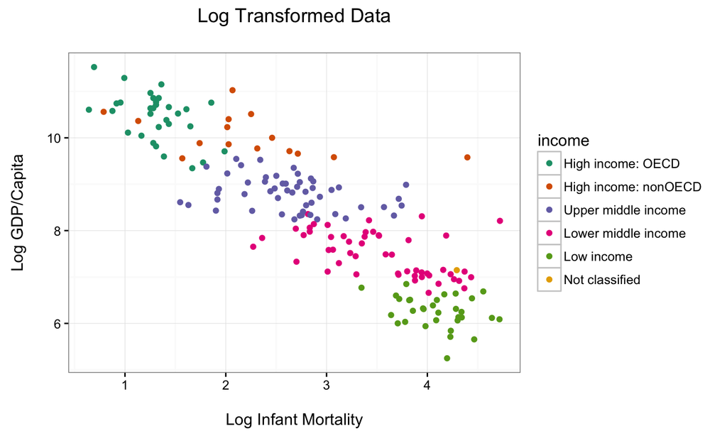

```r
# Create colour vector
Colours <- c("#1B9E77", "#D95F02", "#7570B3",
             "#E7298A", "#66A61E", "#E6AB02")

# Create graph
ggplot(data = InfantNoMiss,
                    aes(log(InfantMortality),
                        log(GDPperCapita))) +
        geom_point(aes(colour = income)) +
        scale_color_manual(values = Colours) +
        xlab("\nLog Infant Mortality") +
        ylab("Log GDP/Capita\n") +
        ggtitle("Log Transformed Data\n") +
        theme_bw()
```

## ggplot2 is very flexible

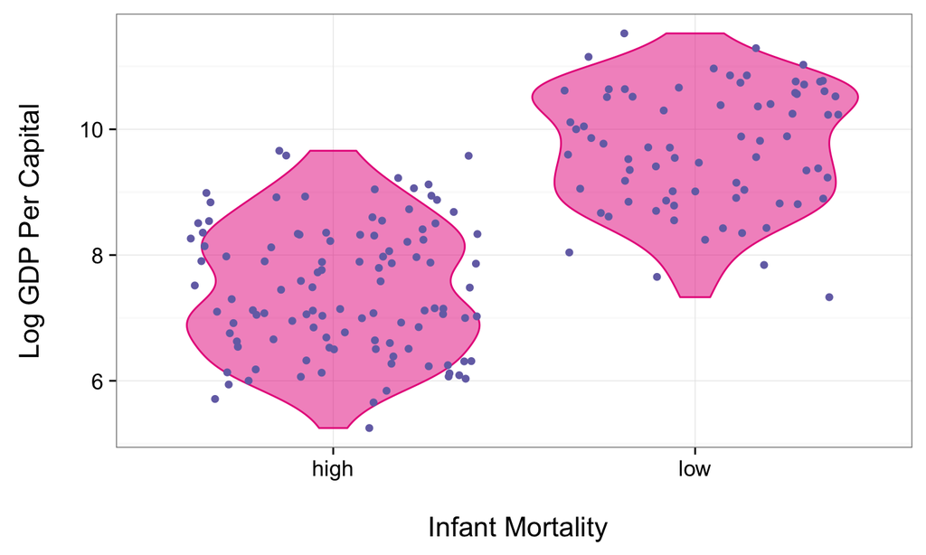

```r
# Create a violin Plot
ggplot(InfantNoMiss, aes(factor(DumMort),
                        log(GDPperCapita))) +
          geom_violin(fill = "#E7298A",
                      colour = "#E7298A",
                      alpha = I(0.5)) +
          geom_jitter(color = "#7570B3") +
          xlab("\n Infant Mortality") +
          ylab("Log GDP Per Capital\n") +
          theme_bw(base_size = 16)
```

## Seminar

Create **tables** and **visualisations** of **descriptive** statistics for your final project in an R Markdown document using the techniques covered in class.

## References

Tufte, Edward R. 2001. *The Visual Display of Quantitative Information*. 2nd ed. Cheshire, CT: Graphics Press.